[figure not shown]

# Cross-Sample Entropy: XSampEn()

Table of Contents

Syntax: References: About XSampEn(): Note: Example 1: Example 2: Example 3:

#### Syntax:

[XSamp, Phi] = XSampEn(Sig, 'm', 2, 'tau', 1, 'r', 0.2*std(Sig), 'Logx', exp(1))

- Sig Time series signals, a N x 2 matrix where N > 10.
- m Embedding dimension, a positive integer.
- tau Time delay, a positive integer.
- r Distance threshold , a positive scalar.
- Logx Logarithm base in Shannon's entropy formula, a positive scalar.
- XSamp Sample entropy estimates, a vector of length m+1. **The first value of XSamp is the zeroth estimate, i.e. , and the last value of XSamp is the estimate for the specified m.
- A The number of matched state vectors for each embedding dimension from 0 to m.
- B The number of matched state vectors for each embedding dimension from 1 to m+1.

#### References:

1. Joshua S Richman and J. Randall Moorman, Physiological time-series analysis using approximate entropy and sample entropy, American Journal of Physiology-Heart and Circulatory Physiology (2000).

#### About XSampEn():

The first value of XSamp is the zeroth estimate, i.e. , and the last value of XSamp is the estimate for the specified m.

#### Note:

In the following examples, signals / data are imported into MatLab using the ExampleData function from EntropyHub.

To use this function as outlined in the examples below, an internet connection is required.

ExampleData accepts any of the following strings:

- 'uniform2' uniformly distributed random numbers in range [0 1]
- 'gaussian2' normally distributed random numbers with mean = 0, and standard deviation = 1
- 'randintegers2' uniformly distributed pseudorandom integers in range [1 8]
- 'lorenz' X, Y, Z components of the Lorenz system (sigma: 10, beta: 8/3, rho: 28) [Xo = 10, Yo = 20, Zo = 10]
- 'henon' X, Y components of the Henon attractor (alpha: 1.4, beta: .3) [Xo = 0, Yo = 0]

#### Example 1:

Import two signals of normally distributed random numbers .

```matlab
X = ExampleData('gaussian2');
```

Calculate the cross-sample entropy for embedding dimensions (m) from 0 to 4.

```matlab
XSamp = XSampEn(X, 'm', 4)
```

XSamp = 1×5

2.1897 2.1854 2.1799 2.1979 2.1539

Select the last value of XSamp to get the cross-sample entropy for m = 4.

```matlab
XSamp(end)
```

ans = 2.1539

Calculate the cross-sample entropy for a maximum embedding dimension (m) of 4 with a time delay (tau) of 2 samples.

```matlab
XSamp = XSampEn(X, 'm', 4, 'tau', 2)
```

XSamp = 1×5

2.1897 2.1933 2.1865 2.1891 2.2435

#### Example 2:

Import a signal of uniformly distributed pseudorandom integers in the range [1, 8]

```matlab
X = ExampleData('randintegers2');
```

Calculate the cross-sample entropy and the number of matched state vectors for a maximum embedding dimension of 5 and time delay (tau) of 5

```matlab
[XSamp, Phi] = XSampEn(X, 'm', 5, 'tau', 5)
```

XSamp = 1×6

2.0798 2.0822 2.0888 2.1335 2.1355 2.5486

Phi = 1×6

1124593 140192 17361 2056 243 19

Change the template matching distance threshold to 0.5*SD(X)

```matlab
[XSamp, Phi] = XSampEn(X, 'm', 5, 'tau', 5, 'r', 0.5*std(X(:)))
```

XSamp = 1×6

1.0731 1.0765 1.0755 1.0746 1.0756 1.0740

Phi = 1×6

3077628 1048800 357781 122153 41665 14235

Change the template matching distance threshold to 1.2

```matlab
[XSamp, Phi] = XSampEn(X, 'm', 5, 'tau', 5, 'r', 1.2)
```

XSamp = 1×6

1.0731 1.0765 1.0755 1.0746 1.0756 1.0740

Phi = 1×6

3077628 1048800 357781 122153 41665 14235

#### Example 3:

Import the x and y components of the Henon system of equations.

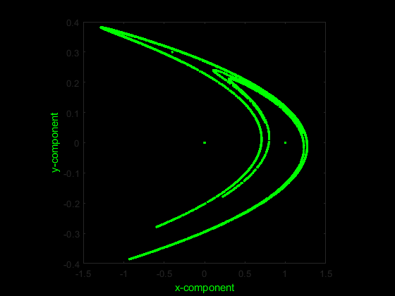

```matlab
Data = ExampleData('henon');
figure('Color', 'k')
plot(Data(:,1), Data(:,2), 'g.')
xlabel('x-component','color','g'), ylabel('y-component','color','g')
set(gca,'color','k'), axis square
```

Calculate the cross-sample entropy in bits (logarithm with base 2) and the number of matched state vectors (Phi) with all other default parameter values.

```matlab
[XSamp, Phi] = XSampEn(Data, 'Logx', 2)
```

XSamp = 1×3

3.7564 Inf NaN

Phi = 1×3

1498432 0 0

As seen here, no state vectors matched for m > 0.